# Coursework Report

*N* removed NAs: 4

*N* removed <18: 23

**Correct typo age:** 20

*N* total clean: 141

| Group | *N* | *M*<sub>age</sub> | % green |
| --- | --- | --- | --- |
| Control | 69 | 21 | 53.1 |
| Experim | 72 | 21 | 36.6 |

| Gender | *N* | *M*<sub>age</sub> | % green |
| --- | --- | --- | --- |
| Male | 66 | 20.9 | 44.4 |
| Female | 47 | 20.8 | 45.4 |
| Other | 28 | 21.4 | 44.0 |

**Main analysis results**

**car:**  
χ<sup>2</sup>(1) = 4.4, *p* = .036

**cleaner:**  
χ<sup>2</sup>(1) = 2.5, *p* = .114

**dishwasher:**  
χ<sup>2</sup>(1) = 3.07, *p* = .080

[interactive chart not shown]

[figure not shown]

[interactive chart not shown]

# Coursework Report

Analysing Data, Spring 2020

# Methods

## Participants

*Participant Age Specifications*

| Mean Age | Standard Deviation | Minimum Age | Maximum Age |
| --- | --- | --- | --- |
| 21 | 2.18 | 18 | 31 |

| Gender | *N*<sub>participants</sub> |
| --- | --- |
| male | 96 |
| female | 78 |
| other | 33 |

| Gender | *N*<sub>participants</sub> |
| --- | --- |
| male | 101 |
| female | 63 |
| other | 51 |

## Design

This experiment was conducted in attempt to verify or disprove the hypothesis that the purchasing of “green products” is driven by status motives. Participants could be placed in the control condition or in the experimental condition. In the control condition, participants are given a neutral story to read whereas in the experimental condition, participants are given a story that does activate status motives. Participants were then asked to make a series of product purchasing choices. For simplicity’s sake, the choices shall be referred to as ‘purchases’ throughout the paper. The products were: car, cleaner, and dishwasher. There are two options that the participants will have to choose from for each of the product: luxury or green. The luxury options are not environmentally friendly and the green alternatives are environmentally friendly but has lesser efficacy than its counterpart. Both options are priced similarly. The operational hypothesis is that the participants in the experimental condition who had their status motives elicited would choose the green products over the luxury in comparison to the participants in the control condition. Using chi-squared test, this paper will attempt to find the likelihood of consumers purchasing green products over luxury products after they have been exposed to a high-status eliciting motive. The probability cut-off point will be p < 0.05. If the p-value exceeds 0.05, it would mean that the null hypothesis is true whereas if the p-value is lower than 0.05, it would mean that the null hypothesis might not be true.

# Results

Below, there are the summarised information and plots about each product and the total purchases that the participants had chosen in their respective conditions.

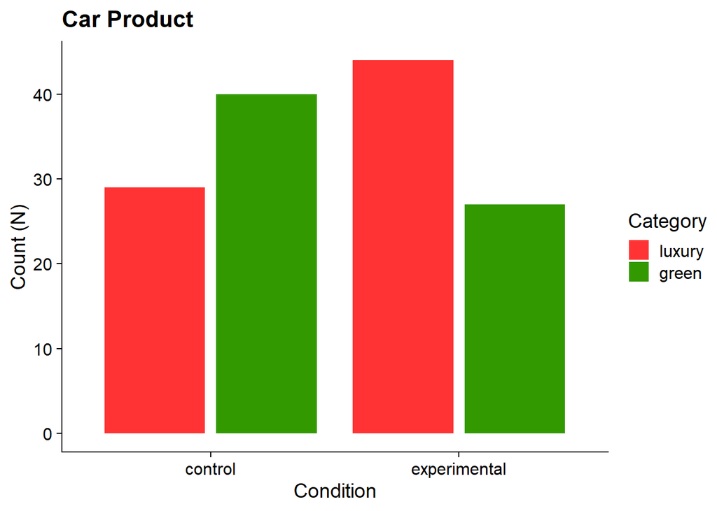

In the control condition for car, there is a 7.86% difference between the green and luxury; with green being the preferred product. In the experimental condition for car, there is a 12.14% difference between the green and luxury; with luxury having more votes.

*Car Product Information*

| Category | Group | *N*<sub>purchases</sub> | *%*<sub>percentage</sub> |
| --- | --- | --- | --- |
| luxury | control | 29 | 20.7 |
| luxury | experimental | 44 | 31.4 |
| green | control | 40 | 28.6 |
| green | experimental | 27 | 19.3 |

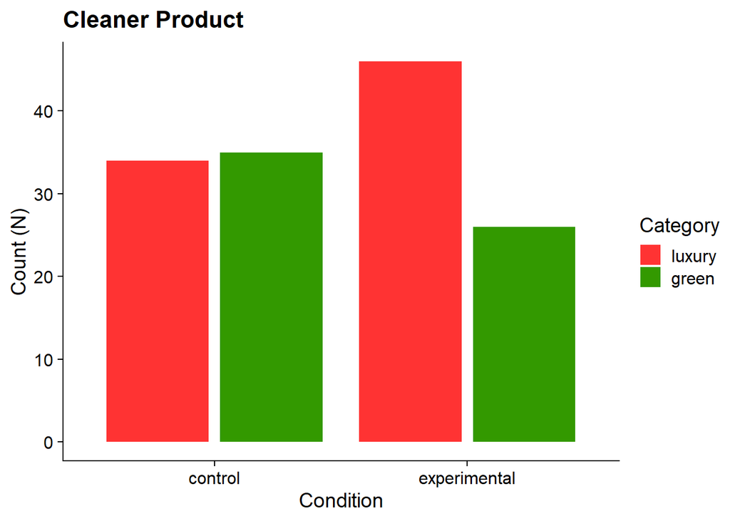

In the control condition for cleaner, there is just a 0.71% difference between the green and luxury; with green being the preferred product. In the experimental condition for cleaner, there is a 14.18% difference between the green and luxury; with luxury having more votes.

*Cleaner Product Information*

| Category | Group | *N*<sub>purchases</sub> | *%*<sub>percentage</sub> |
| --- | --- | --- | --- |
| luxury | control | 34 | 24.1 |
| luxury | experimental | 46 | 32.6 |
| green | control | 35 | 24.8 |
| green | experimental | 26 | 18.4 |

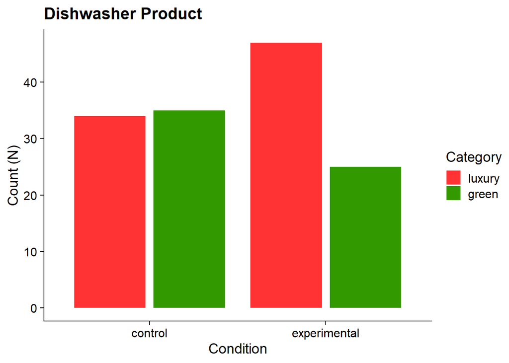

In the control condition for the dishwasher, there is a 0.71% difference between the green and luxury; with green being the preferred product. In the experimental condition, there is a staggering 15.6% difference between the green and luxury; with luxury having more votes. This is by far the largest difference.

*Dishwasher Product Information*

| Category | Group | *N*<sub>purchases</sub> | *%*<sub>percentage</sub> |
| --- | --- | --- | --- |
| luxury | control | 34 | 24.1 |
| luxury | experimental | 47 | 33.3 |
| green | control | 35 | 24.8 |
| green | experimental | 25 | 17.7 |

Before we can disprove the hypothesis, we need to conduct a chi-squared testing is necessary to see if the observed distribution has occured due to chance or because there is a real, significant correlation.

Expected Frequencies for Car Product

|  | luxury | green |
| --- | --- | --- |
| control | 36 | 33 |
| experimental | 37 | 34 |

Expected Frequencies for Cleaner Product

|  | luxury | green |
| --- | --- | --- |
| control | 39.1 | 29.9 |
| experimental | 40.9 | 31.1 |

The chi-squared for the cleaner product is *χ*<sup>2</sup>(1) = 2.5 with a *p*-value of < .113. The *p*-value is in accordance with the null hypothesis.

Expected Frequencies for Dishwasher Product

|  | luxury | green |
| --- | --- | --- |
| control | 39.6 | 29.4 |
| experimental | 41.4 | 30.6 |

The only product that refuses the null hypothesis is the car. This implies that might be a relationship between the condition that the participant is in (control or experimental) and the choice of product versions (luxury or green) is correlated. This is because the *p*-value is too small for it to be a mere coincidence.

This information however, does not inform us of the relationship shared between the condition and the choice of product versions for cars. The information only manages to disprove the null hypothesis, informing us that there is indeed a relationship. But if we were to guess, it might be that there is a relationship between luxury product choices and the stories that can elicit status-achieving motives.

# Discussion

This also suggests that some products have a more significant relationship to status than others. For example, a car is considered a sign of higher status than a cleaner would be. This might affect the decision to purchase a more luxurious option. A cleaner on the other hand, is a mundane product which participants would not have to splurge on to show power and status.

Unlike the original study by Griskevicius et al. (2010), this study proves that there is close to no relationship between the motivation to gain status and the attractiveness of the green product in comparison to the luxury product. On the contrary, the data in this study shows that motivation to gain status may increase the attractiveness of luxury products. This is similar to the idea mentioned in Griskevicius et al. (2010)’s paper wherein the motivation to purchase green products decreases if the green product is cheaper than the luxury product. This is because it explicitly pinpoints the lack of status that the individual has since he/she is unable to afford to purchase the luxurious option. Their paper found that without the green product being the more costly option, it would have no attractiveness or appeal to consumers.

On the other hand, the results are in line with Sundie et al. (2011)’s paper on conspicuous consumption. From the results we found, luxury products, insinuating a hefty price tag, can be a sign of conspicious spending. While they are priced similarly, the illusion of a luxe option may be more appealing for participants as it contributes to the perception that they are of higher status. While proven to not be an effective strategy for long-term mating in the paper, it was still effective at building self-perception, at least in men. The paper suggests that there is a niche group (women who want short-term mating) who will be susceptible to such conspicuous charms. Given that the prices of the two product versions in this experiment being the same, it might be the concept of a luxury product that appeals to participants rather than the display of conspicuous spending.

At any case, the strategy of purchasing luxury goods over green goods seems to be more prominent than the purchasing of green products because at the base of it all. Brand names play a significant part in today’s society as it becomes the epitome of status (Evardsson, Tronvoll, & Gruber, 2011). Society has dictated that certain brands are only affordable to a certain elite class of people. As such, ownership of certain brands dictates power and status that belongs to just the elite percentage of the global population. This is justified by the motivation to purchase counterfeit branded products. Mainly, it is to attain the standards of their personal social goals despite it being something out of their budget (Wilcox, Kim, & Sen, 2009).

Another approach to the motivation might be to fit in to the elite class who are able to afford luxe products (Wilcox, Kim, & Sen, 2009). It’s approval they crave from the elite class and the one way they can obtain it is by purchasing luxe products. By purchasing a luxury brand, individuals are able to not just fit comfortably in the higher socioeconomic class, they are able to avoid the mundane green product that may be perceived as counterfeits to the luxe products even though it is not. Their primary motivation to avoid such green products may stem from the fear of negative social repurcussions of failing to ‘fit in’ with the lives of the higher socioeconomic class (Wilcox, Kim & Sen, 2009).

Ultimately, the role of luxe products in society sends a message of one’s status and power as it displays the ability to afford expensive, luxurious alternatives (Sun, 2011). The more luxurious products one has, the higher they stand in the social hierarchy ladder. Since one’s status is now reflected by their belongings and their lifestyles, luxe products become a tangible method to establish one’s social class. This is similar to Sundie et al. (2011)’s paper, it traces back to the concept of conspicious spending.

The data is able to get close to equal participants for both conditions. It has captured the different levels of purchasing decisions. It has accurate methods of measuring association.

This data, however, does come with a few limitations. Firstly, the variety of the products that participants get to choose from is homogenous in pricing. The three products can be considered as investments since they are all non-single-use utilities that the average individuals will purchase just a few times over the course of their life. Inclusion of cheaper, day-to-day use products such as tissues or food items may generate different conclusions.

Some of the products such as cars may be considered a privilege as well for some families. Low-income households may live their life without cars or dishwashers. The data may not be an accurate representation for the general population. It also raises the concern the products themselves are at base, already a sign of status. This varies across different populations and cultures. The data fails to take such detrimental factors into account.

Further research may be conducted regarding the social implications of purchasing green products over mainstream products instead of luxury.

# References

Edvardsson, B., Tronvoll, B., & Gruber, T. (2011). Expanding understanding of service exchange and value co-creation: A social construction approach. Journal of the Academy of Marketing Science, 39(2), 327–339. https://doi.org/10.1007/s11747-010-0200-y

Griskevicius, V., Tybur, J. M., & Van den Bergh, B. (2010). Going Green to Be Seen: Status, Reputation, and Conspicuous Conservation. Journal of Personality and Social Psychology, 98(3), 392–404. https://doi.org/10.1037/a0017346

W. (2011). Consumption of luxury fashion brands : The Motives of Generation Y Consumers in China Ming Wei Sun Auckland University of Technology. Review Literature And Arts Of The Americas, (June), 1–125.

Sundie, J. M., Kenrick, D. T., Griskevicius, V., Tybur, J. M., Vohs, K. D., & Beal, D. J. (2011). Peacocks, Porsches, and Thorstein Veblen: Conspicuous Consumption as a Sexual Signaling System. Journal of Personality and Social Psychology, 100(4), 664–680. https://doi.org/10.1037/a0021669

Wilcox, K., Kim, H. M., & Sen, S. (2009). Why do consumers buy counterfeit luxury brands? Journal of Marketing Research, 46(2), 247–259. https://doi.org/10.1509/jmkr.46.2.247